## Lab Worksheet 2

We will be working with the `msleep` data set that is provided with ggplot2. The data set contains information about the sleep habits of 83 mammals. Enter `?msleep` on the R console to learn more about the dataset.

```r
head(msleep)
```

```
## # A tibble: 6 x 11
##   name  genus vore  order conservation sleep_total sleep_rem sleep_cycle
##   <chr> <chr> <chr> <chr> <chr>              <dbl>     <dbl>       <dbl>
## 1 Chee… Acin… carni Carn… lc                  12.1      NA        NA
## 2 Owl … Aotus omni  Prim… <NA>                17         1.8      NA
## 3 Moun… Aplo… herbi Rode… nt                  14.4       2.4      NA
## 4 Grea… Blar… omni  Sori… lc                  14.9       2.3       0.133
## 5 Cow   Bos   herbi Arti… domesticated         4         0.7       0.667
## 6 Thre… Brad… herbi Pilo… <NA>                14.4       2.2       0.767
## # … with 3 more variables: awake <dbl>, brainwt <dbl>, bodywt <dbl>
```

**Problem 1:** Make the following plots: (i) a plot of total time awake vs. body weight, colored by `vore` (carnivore, herbivore, etc.); (ii) a plot of body weight vs. brain weight, colored by “vore”. When you plot body weight and/or brain weight, consider whether a linear scale or a logarithmic scale seems more appropriate, and explain your reasoning in 1-2 sentences. **HINT:** Use the functions `scale_x_log10()` and `scale_y_log10()` to change the scales.

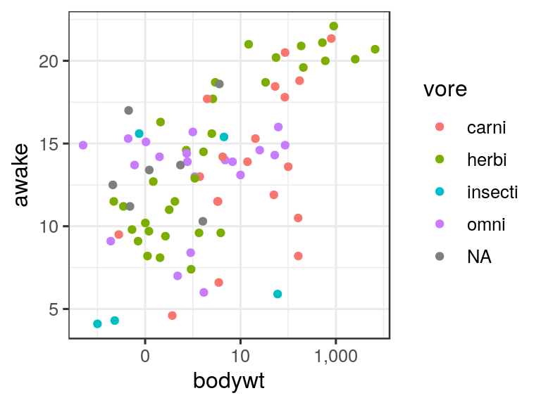

```r
ggplot(msleep, aes(x = bodywt, y = awake, color = vore)) +
  geom_point() +
  scale_x_log10(labels = comma)
```

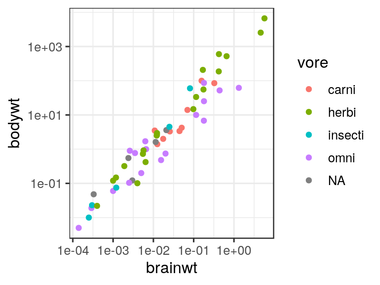

```r
ggplot(msleep, aes(x = brainwt, y = bodywt, color = vore)) +
  geom_point() +
  scale_x_log10() +
  scale_y_log10()
```

Log scales are more appropriate for both body weight and brain weight because there are a few species that have much larger values than most other species. If we were to use a linear scale, these outlying species would require axis ranges that are too wide to resolve any details for the majority of the species.

**Problem 2:** Plot `sleep_total` verses `bodywt` for **ONLY** carnivores, herbivores, and omnivores. Facet this plot by `vore`, and then fit a curve to each facet using `geom_smooth`. In 1-2 sentences, make one observation about total time asleep and body weight.

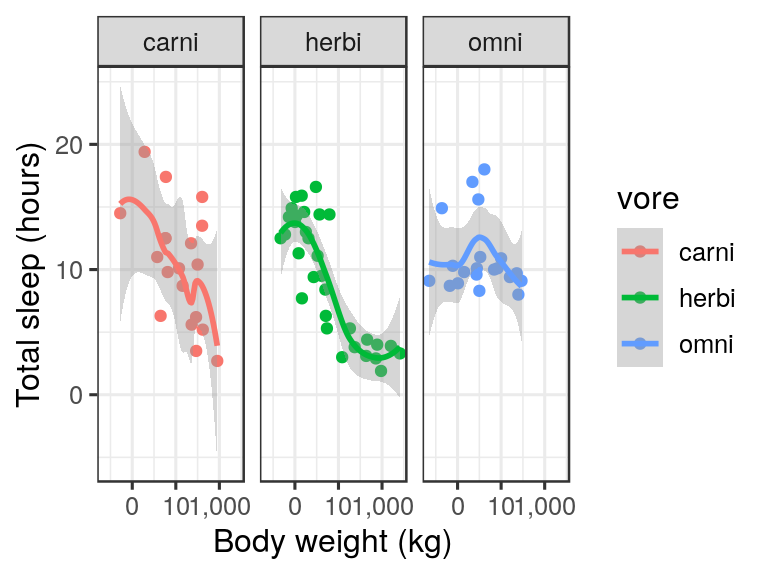

```r
msleep2 <- msleep %>%
  filter(vore == "omni" | vore == "carni" | vore == "herbi")

ggplot(msleep2, aes(x = bodywt, y = sleep_total, color = vore)) +
  geom_point() +
  geom_smooth() +
  facet_wrap(~vore) +
  scale_x_log10(label = comma) +
  xlab("Body weight (kg)") +
  ylab("Total sleep (hours)")
```

**Problem 3 (if time):** Explain the difference between `geom_line()` and `geom_path()`. Make up a simple data set (5-10 data points), plot it twice, once using `geom_line()` and once using `geom_path()`, and explain why each plot looks the way it does.

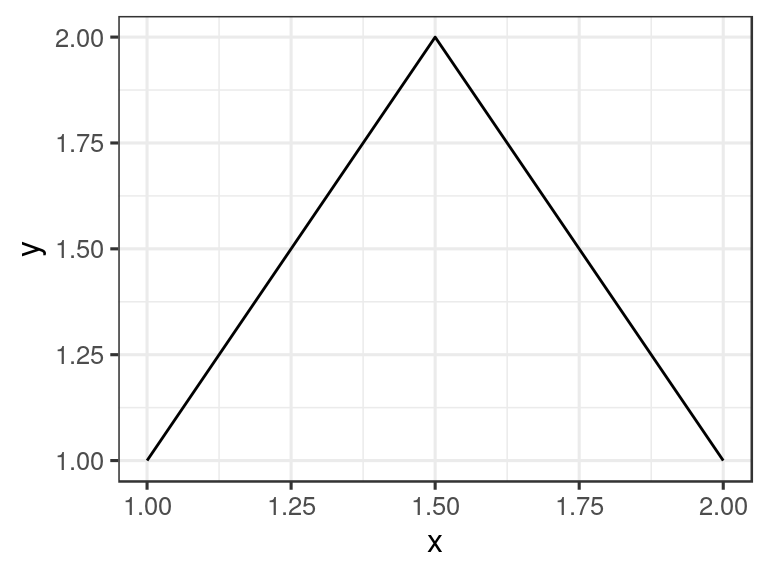

```r
d <- data.frame(x = c(1, 2, 1.5, 1), y = c(1, 1, 2, 1))
ggplot(d, aes(x = x, y = y)) + geom_line()
```

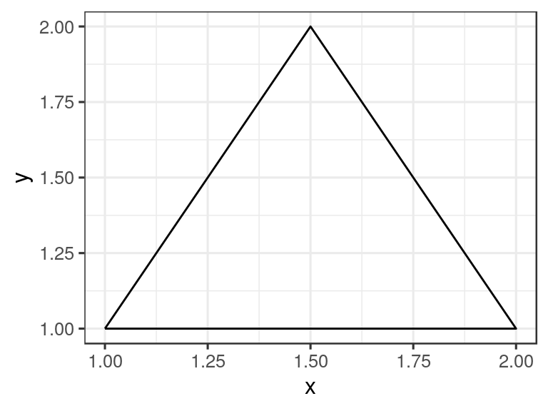

```r
ggplot(d, aes(x = x, y = y)) + geom_path()
```

`geom_line()` connects data points in the order from smallest to largest x value. `geom_path()`, by contrast, connects data points in the order in which they appear in the data frame. The following data set produces an open triangle with `geom_line()` and a closed triangle with `geom_path()`.